# Generate opportunities for win probability forecasting

## Generate Dimensions

Each opportunity has following dimensions: upload date, opportunity name, customer, industry, region, marketing campaign, customer type, opportunity owner, forecast category, stage, product, price, quantity, value, estimated close date, created

```r
# Upload and estimated close date
created_dates <- seq.Date(from = as.Date("2017-01-01"), to = as.Date("2020-01-01"), by = "day")
# fc_dates <- seq.Date(from = as.Date("2019-10-01"), to = as.Date("2021-10-01"), by = "week")

# Opportunity name
opp_names <- c()
for (i in 1:1200){
  name <- paste(c('Opportunity', i), collapse = '_')
  opp_names[i] <- name
}

# Customer
customer_names <- c()
for (i in 1:700){
  name <- paste(c('Customer', i), collapse = '_')
  customer_names[i] <- name
}

# Industry
industry_names <- c()
for (i in 1:10){
  name <- paste(c('Industry', i), collapse = '_')
  industry_names[i] <- name
}

# Region
region_names <- c()
for (i in 1:10){
  name <- paste(c('Region', i), collapse = '_')
  region_names[i] <- name
}

# Campaign
campaign_names <- c()
for (i in 1:6){
  name <- paste(c('Campaign', i), collapse = '_')
  campaign_names[i] <- name
}

# Customer type
customer_types <- c("New Business", "Existing Business")

# Opportunity owner
owner_names <- c()
for (i in 1:15){
  name <- paste(c('Owner', i), collapse = '_')
  owner_names[i] <- name
}

# Stage
stage_names <- c("1. Marketing", "2. Prospect", "3. Discovery", "4. Identify Pains", "5. Value Proposition", "6. Final bid", "Won", "Lost")

# Product
product_names <- c()
for (i in 1:12){
  name <- paste(c('Product', i), collapse = '_')
  product_names[i] <- name
}

# Fuction to generate probabilities
generate_random_probabilities <- function(n){
  nums <- runif(n, 0, 1)
  return(nums/sum(nums))
}
```

## Create the opportunities for new and existing businesses

First create new businesses, then take part of them to define as existing business. Here we add only the dimensions, which are static for a particular customer, these are: customer name, region, industry and owner.

```r
# Divide the opportunity names

new_business <- opp_names[1:length(customer_names)]
existing_business <- opp_names[(length(customer_names)+1):length(opp_names)]

# Create new businesses

new_business_df <- data.frame(new_business)
colnames(new_business_df) <- 'Opportunity_Name'
new_business_df$Customer <- customer_names
new_business_df$Region <- sample(x = region_names, size = length(new_business), replace = TRUE, prob = generate_random_probabilities(length(region_names)))
new_business_df$Industry <- sample(x = industry_names, size = length(new_business), replace = TRUE, prob = generate_random_probabilities(length(industry_names)))
new_business_df$Customer_Type <- 'New Business'
new_business_df$Owner <- sample(x = owner_names, size = length(new_business), replace = TRUE, prob = generate_random_probabilities(length(owner_names)))

# Create existing business
library('dplyr')
existing_business_df <- sample_n(new_business_df, length(existing_business))
existing_business_df$Customer_Type <- 'Existing Business'
existing_business_df$Opportunity_Name <- existing_business

opps_complete <- rbind(new_business_df, existing_business_df)
# print(opps_complete)
```

## Add further dimensions

Now the dimensions marketing campaign, creation date and stage for all opporunities are added

```r
opps_complete$Campaign <- sample(x = campaign_names, size = nrow(opps_complete), replace = TRUE, prob = generate_random_probabilities(length(campaign_names)))
stage_probabilities <- c(0.8, 0.125, 0.06, 0.005, 0.005, 0.005, 0.0, 0.0)
opps_complete$Stage <- sample(x = stage_names, size = nrow(opps_complete), replace = TRUE, prob = stage_probabilities)
opps_complete$Created <- sample(x = created_dates, size = nrow(opps_complete), replace = TRUE)
```

```r
library('dplyr')

opps_complete <- mutate_if(opps_complete, is.character, as.factor)
summary(opps_complete, maxsum = 20)
```

```
        Opportunity_Name         Customer          Region           Industry             Customer_Type      Owner           Campaign
 Opportunity_1  :   1    Customer_1  :   2   Region_1 :189   Industry_1 : 75   Existing Business:500   Owner_1 :104   Campaign_1:227
 Opportunity_10 :   1    Customer_10 :   2   Region_10: 56   Industry_10: 37   New Business     :700   Owner_10: 11   Campaign_2:223
 Opportunity_100:   1    Customer_100:   2   Region_2 : 36   Industry_2 :287                           Owner_11: 43   Campaign_3:247
 Opportunity_101:   1    Customer_101:   2   Region_3 :268   Industry_3 : 96                           Owner_12: 68   Campaign_4: 86
 Opportunity_102:   1    Customer_102:   2   Region_4 :173   Industry_4 :238                           Owner_13: 24   Campaign_5:315
 Opportunity_103:   1    Customer_103:   2   Region_5 :228   Industry_5 : 21                           Owner_14:128   Campaign_6:102
 Opportunity_104:   1    Customer_104:   2   Region_6 :147   Industry_6 : 43                           Owner_15: 39
 Opportunity_105:   1    Customer_105:   2   Region_7 : 58   Industry_7 : 53                           Owner_2 : 53
 Opportunity_106:   1    Customer_106:   2   Region_8 : 21   Industry_8 : 76                           Owner_3 :125
 Opportunity_107:   1    Customer_107:   2   Region_9 : 24   Industry_9 :274                           Owner_4 :102
 Opportunity_108:   1    Customer_108:   2                                                             Owner_5 :141
 Opportunity_109:   1    Customer_109:   2                                                             Owner_6 : 66
 Opportunity_11 :   1    Customer_11 :   2                                                             Owner_7 :102
 Opportunity_110:   1    Customer_110:   2                                                             Owner_8 : 98
 Opportunity_111:   1    Customer_113:   2                                                             Owner_9 : 96
 Opportunity_112:   1    Customer_115:   2
 Opportunity_113:   1    Customer_116:   2
 Opportunity_114:   1    Customer_117:   2
 Opportunity_115:   1    Customer_118:   2
 (Other)        :1181    (Other)     :1162
                  Stage        Created
 1. Marketing        :961   Min.   :2017-01-01
 2. Prospect         :129   1st Qu.:2017-10-13
 3. Discovery        : 86   Median :2018-06-21
 4. Identify Pains   :  8   Mean   :2018-07-03
 5. Value Proposition:  8   3rd Qu.:2019-04-09
 6. Final bid        :  8   Max.   :2020-01-01
```

```r
opps_complete$DayOfWeek <- as.POSIXlt(opps_complete$Created)$wday
opps_complete$DaysToAdd <- (4 - opps_complete$DayOfWeek)%%7
opps_complete$Upload_date <- as.Date(opps_complete$Created) + opps_complete$DaysToAdd
opps_complete <- subset(opps_complete, select = -c(DayOfWeek, DaysToAdd))
print(opps_complete)
```

|  | Opportunity_Name | Customer | Region | Industry | Customer_Type | Owner | Campaign | Stage | Created | Upload_date |
| --- | --- | --- | --- | --- | --- | --- | --- | --- | --- | --- |
| 1 | Opportunity_1 | Customer_1 | Region_4 | Industry_2 | New Business | Owner_11 | Campaign_5 | 1. Marketing | 2018-07-25 | 2018-07-26 |
| 2 | Opportunity_2 | Customer_2 | Region_6 | Industry_4 | New Business | Owner_1 | Campaign_5 | 3. Discovery | 2019-02-03 | 2019-02-07 |
| 3 | Opportunity_3 | Customer_3 | Region_1 | Industry_9 | New Business | Owner_14 | Campaign_3 | 1. Marketing | 2018-11-24 | 2018-11-29 |
| 4 | Opportunity_4 | Customer_4 | Region_4 | Industry_2 | New Business | Owner_15 | Campaign_5 | 2. Prospect | 2019-07-30 | 2019-08-01 |
| 5 | Opportunity_5 | Customer_5 | Region_5 | Industry_6 | New Business | Owner_14 | Campaign_4 | 1. Marketing | 2018-10-12 | 2018-10-18 |
| 6 | Opportunity_6 | Customer_6 | Region_5 | Industry_7 | New Business | Owner_15 | Campaign_2 | 5. Value Proposition | 2018-04-12 | 2018-04-12 |
| 7 | Opportunity_7 | Customer_7 | Region_5 | Industry_4 | New Business | Owner_1 | Campaign_3 | 2. Prospect | 2018-03-25 | 2018-03-29 |
| 8 | Opportunity_8 | Customer_8 | Region_1 | Industry_10 | New Business | Owner_7 | Campaign_1 | 1. Marketing | 2019-05-31 | 2019-06-06 |
| 9 | Opportunity_9 | Customer_9 | Region_4 | Industry_2 | New Business | Owner_2 | Campaign_5 | 1. Marketing | 2017-02-10 | 2017-02-16 |
| 10 | Opportunity_10 | Customer_10 | Region_3 | Industry_4 | New Business | Owner_7 | Campaign_3 | 1. Marketing | 2017-01-03 | 2017-01-05 |

[output cut: 990 more lines]

```r
NA
```

## Generate closing date

For lost and won opportunities “upload date” will be taken. For the 6. stage “final Bid” four weeks, for the 5. stage six weeks and so on. For the 1. stage we add 22 weeks.

```r
opps_complete$Expected_closing <- ifelse((opps_complete$Stage == "Won" | opps_complete$Stage == "Lost"), 0,
                                      ifelse(opps_complete$Stage == "6. Final bid", 28,
                                             ifelse(opps_complete$Stage == "5. Value Proposition", 42,
                                                    ifelse(opps_complete$Stage == "4. Identify Pains", 63,
                                                           ifelse(opps_complete$Stage == "3. Discovery", 91,
                                                                  ifelse(opps_complete$Stage == "2. Prospect", 112,
                                                                         ifelse(opps_complete$Stage == "1. Marketing", 154, NA)))))))

print(opps_complete)
```

|  | Opportunity_Name | Customer | Region | Industry | Customer_Type | Owner | Campaign | Stage | Created | Upload_date | Expected_closing |
| --- | --- | --- | --- | --- | --- | --- | --- | --- | --- | --- | --- |
| 1 | Opportunity_1 | Customer_1 | Region_4 | Industry_2 | New Business | Owner_11 | Campaign_5 | 1. Marketing | 2018-07-25 | 2018-07-26 | 154 |
| 2 | Opportunity_2 | Customer_2 | Region_6 | Industry_4 | New Business | Owner_1 | Campaign_5 | 3. Discovery | 2019-02-03 | 2019-02-07 | 91 |
| 3 | Opportunity_3 | Customer_3 | Region_1 | Industry_9 | New Business | Owner_14 | Campaign_3 | 1. Marketing | 2018-11-24 | 2018-11-29 | 154 |
| 4 | Opportunity_4 | Customer_4 | Region_4 | Industry_2 | New Business | Owner_15 | Campaign_5 | 2. Prospect | 2019-07-30 | 2019-08-01 | 112 |
| 5 | Opportunity_5 | Customer_5 | Region_5 | Industry_6 | New Business | Owner_14 | Campaign_4 | 1. Marketing | 2018-10-12 | 2018-10-18 | 154 |
| 6 | Opportunity_6 | Customer_6 | Region_5 | Industry_7 | New Business | Owner_15 | Campaign_2 | 5. Value Proposition | 2018-04-12 | 2018-04-12 | 42 |
| 7 | Opportunity_7 | Customer_7 | Region_5 | Industry_4 | New Business | Owner_1 | Campaign_3 | 2. Prospect | 2018-03-25 | 2018-03-29 | 112 |
| 8 | Opportunity_8 | Customer_8 | Region_1 | Industry_10 | New Business | Owner_7 | Campaign_1 | 1. Marketing | 2019-05-31 | 2019-06-06 | 154 |
| 9 | Opportunity_9 | Customer_9 | Region_4 | Industry_2 | New Business | Owner_2 | Campaign_5 | 1. Marketing | 2017-02-10 | 2017-02-16 | 154 |
| 10 | Opportunity_10 | Customer_10 | Region_3 | Industry_4 | New Business | Owner_7 | Campaign_3 | 1. Marketing | 2017-01-03 | 2017-01-05 | 154 |

[output cut: 990 more lines]

```r
NA
```

## Add products

First, let’s assign prices to products

```r
# Product-Price mapping
prices <-  floor(runif(length(product_names), min = 1, max = 20))
prices <- prices*100
product_prices <- data.frame(product_names, prices)
colnames(product_prices)[1] <- 'Product'
print(product_prices)
```

| Product | prices |
| --- | --- |
| Product_1 | 1500 |
| Product_2 | 1700 |
| Product_3 | 1500 |
| Product_4 | 1900 |
| Product_5 | 600 |
| Product_6 | 300 |
| Product_7 | 1500 |
| Product_8 | 300 |
| Product_9 | 300 |
| Product_10 | 1300 |

[output cut: 2 more lines]

Now we can add products to the opportunities. To each opportunity some random number of products between 3 and 10 will be randomly chosen from the product list, with random generated probability

```r
# Add products
library(tidyverse)
opportunities_df <- data.frame()
for (row in 1:nrow(opps_complete)){
  line <- opps_complete[row,]
  opp_products <- sample( x = product_names, size = sample(3:10, 1), replace = FALSE, prob = generate_random_probabilities(length(product_names)))
  new_line <- data.frame(opp_products)
  colnames(new_line) <- 'Product'
  new_line$Opportunity_Name <- line$Opportunity_Name
  new_line$Customer <- line$Customer
  new_line$Region <- line$Region
  new_line$Industry <- line$Industry
  new_line$Customer_Type <- line$Customer_Type
  new_line$Owner <- line$Owner
  new_line$Campaign <- line$Campaign
  new_line$Stage <- line$Stage
  new_line$Created <- line$Created
  new_line$Upload_date <- line$Upload_date
  new_line$Expected_closing <- line$Expected_closing
  new_line$Price <- product_prices$prices[match(new_line$Product, product_prices$Product)]
  new_line$Amount <- floor(runif(nrow(new_line), min = 1, max = 10))

  opportunities_df <- rbind(opportunities_df, new_line)
}


print(opportunities_df)
```

| Product | Opportunity_Name | Customer | Region | Industry | Customer_Type | Owner | Campaign | Stage | Created | Upload_date | Expected_closing | Price | Amount |
| --- | --- | --- | --- | --- | --- | --- | --- | --- | --- | --- | --- | --- | --- |
| Product_9 | Opportunity_1 | Customer_1 | Region_4 | Industry_2 | New Business | Owner_11 | Campaign_5 | 1. Marketing | 2018-07-25 | 2018-07-26 | 154 | 300 | 4 |
| Product_6 | Opportunity_1 | Customer_1 | Region_4 | Industry_2 | New Business | Owner_11 | Campaign_5 | 1. Marketing | 2018-07-25 | 2018-07-26 | 154 | 300 | 8 |
| Product_5 | Opportunity_1 | Customer_1 | Region_4 | Industry_2 | New Business | Owner_11 | Campaign_5 | 1. Marketing | 2018-07-25 | 2018-07-26 | 154 | 600 | 5 |
| Product_4 | Opportunity_1 | Customer_1 | Region_4 | Industry_2 | New Business | Owner_11 | Campaign_5 | 1. Marketing | 2018-07-25 | 2018-07-26 | 154 | 1900 | 8 |
| Product_12 | Opportunity_1 | Customer_1 | Region_4 | Industry_2 | New Business | Owner_11 | Campaign_5 | 1. Marketing | 2018-07-25 | 2018-07-26 | 154 | 700 | 8 |
| Product_11 | Opportunity_1 | Customer_1 | Region_4 | Industry_2 | New Business | Owner_11 | Campaign_5 | 1. Marketing | 2018-07-25 | 2018-07-26 | 154 | 1100 | 8 |
| Product_1 | Opportunity_1 | Customer_1 | Region_4 | Industry_2 | New Business | Owner_11 | Campaign_5 | 1. Marketing | 2018-07-25 | 2018-07-26 | 154 | 1500 | 2 |
| Product_3 | Opportunity_1 | Customer_1 | Region_4 | Industry_2 | New Business | Owner_11 | Campaign_5 | 1. Marketing | 2018-07-25 | 2018-07-26 | 154 | 1500 | 6 |
| Product_9 | Opportunity_2 | Customer_2 | Region_6 | Industry_4 | New Business | Owner_1 | Campaign_5 | 3. Discovery | 2019-02-03 | 2019-02-07 | 91 | 300 | 4 |
| Product_2 | Opportunity_2 | Customer_2 | Region_6 | Industry_4 | New Business | Owner_1 | Campaign_5 | 3. Discovery | 2019-02-03 | 2019-02-07 | 91 | 1700 | 1 |

[output cut: 990 more lines]

## Now let’s generate the weekly updates for each opportunity.

```r
check_val <- TRUE
last_stage <- opportunities_df

# Define the probabilities for coming into next stage for worst case

sample_first_stage_wc <- c("1. Marketing", "2. Prospect", "3. Discovery", "4. Identify Pains", "5. Value Proposition", "6. Final bid", "Won", "Lost")
probability_first_stage_wc <- c(0.8, 0.1, 0.03, 0.02, 0.02, 0.02, 0.002, 0.008)

sample_second_stage_wc <- c("2. Prospect", "3. Discovery", "4. Identify Pains", "5. Value Proposition", "6. Final bid", "Won", "Lost")
probability_second_stage_wc <-  c(0.7, 0.1, 0.04, 0.02, 0.02, 0.02, 0.1)

sample_third_stage_wc <- c("3. Discovery", "4. Identify Pains", "5. Value Proposition", "6. Final bid", "Won", "Lost")
probability_third_stage_wc <-  c(0.6, 0.12, 0.04, 0.02, 0.02, 0.2)

sample_fourth_stage_wc <- c("4. Identify Pains", "5. Value Proposition", "6. Final bid", "Won", "Lost")
probability_fourth_stage_wc <-  c(0.5, 0.14, 0.04, 0.02, 0.3)

sample_fifth_stage_wc <- c("5. Value Proposition", "6. Final bid", "Won", "Lost")
probability_fifth_stage_wc <-  c(0.4, 0.18, 0.02, 0.4)

sample_sixth_stage_wc <- c("6. Final bid", "Won", "Lost")
probability_sixth_stage_wc <-  c(0.5, 0.2, 0.3)

# Probabilities for normal case

sample_first_stage_nc <- c("1. Marketing", "2. Prospect", "3. Discovery", "4. Identify Pains", "5. Value Proposition", "6. Final bid", "Won", "Lost")
probability_first_stage_nc <- c(0.6, 0.3, 0.03, 0.02, 0.02, 0.02, 0.002, 0.008)

sample_second_stage_nc <- c("2. Prospect", "3. Discovery", "4. Identify Pains", "5. Value Proposition", "6. Final bid", "Won", "Lost")
probability_second_stage_nc <-  c(0.6, 0.25, 0.04, 0.02, 0.02, 0.02, 0.05)

sample_third_stage_nc <- c("3. Discovery", "4. Identify Pains", "5. Value Proposition", "6. Final bid", "Won", "Lost")
probability_third_stage_nc <-  c(0.5, 0.3, 0.06, 0.02, 0.02, 0.1)

sample_fourth_stage_nc <- c("4. Identify Pains", "5. Value Proposition", "6. Final bid", "Won", "Lost")
probability_fourth_stage_nc <-  c(0.5, 0.3, 0.08, 0.02, 0.1)

sample_fifth_stage_nc <- c("5. Value Proposition", "6. Final bid", "Won", "Lost")
probability_fifth_stage_nc <-  c(0.4, 0.3, 0.2, 0.1)

sample_sixth_stage_nc <- c("6. Final bid", "Won", "Lost")
probability_sixth_stage_nc <-  c(0.3, 0.6, 0.1)

# Probabilities for best case

sample_first_stage_bc <- c("1. Marketing", "2. Prospect", "3. Discovery", "4. Identify Pains", "5. Value Proposition", "6. Final bid", "Won", "Lost")
probability_first_stage_bc <- c(0.5, 0.4, 0.03, 0.02, 0.02, 0.02, 0.002, 0.008)

sample_second_stage_bc <- c("2. Prospect", "3. Discovery", "4. Identify Pains", "5. Value Proposition", "6. Final bid", "Won", "Lost")
probability_second_stage_bc <-  c(0.5, 0.35, 0.04, 0.02, 0.02, 0.02, 0.05)

sample_third_stage_bc <- c("3. Discovery", "4. Identify Pains", "5. Value Proposition", "6. Final bid", "Won", "Lost")
probability_third_stage_bc <-  c(0.4, 0.4, 0.06, 0.02, 0.02, 0.1)

sample_fourth_stage_bc <- c("4. Identify Pains", "5. Value Proposition", "6. Final bid", "Won", "Lost")
probability_fourth_stage_bc <-  c(0.4, 0.4, 0.08, 0.02, 0.1)

sample_fifth_stage_bc <- c("5. Value Proposition", "6. Final bid", "Won", "Lost")
probability_fifth_stage_bc <-  c(0.3, 0.4, 0.2, 0.1)

sample_sixth_stage_bc <- c("6. Final bid", "Won", "Lost")
probability_sixth_stage_bc <-  c(0.2, 0.8, 0.0)

owners_bc <- c('Owner_1', 'Owner_2', 'Owner_3', 'Owner_5', 'Owner_5')
owners_wc <- c('Owner_6', 'Owner_7', 'Owner_8', 'Owner_9', 'Owner_10')
owners_nc <- c('Owner_11', 'Owner_12', 'Owner_13', 'Owner_14', 'Owner_15')

industry_bc <- c('Industry_1', 'Industry_2', 'Industry_3')
industry_wc <- c('Industry_4', 'Industry_5', 'Industry_6')
industry_nc <- c('Industry_7', 'Industry_8', 'Industry_9', 'Industry_10')

region_bc <- c('Region_1', 'Region_2', 'Region_3')
region_wc <- c('Region_4', 'Region_5', 'Region_6')
region_nc <- c('Region_7', 'Region_8', 'Region_9', 'Region_10')



max_date <- '2020-01-01'

library(dplyr)
data_complete <- data.frame()
while(check_val){
  new_stage <- last_stage
  new_stage$Upload_date <- last_stage$Upload_date + 7
  new_stage_new <- data.frame()
  for (opportunity in opp_names){
    opportunity_data <- new_stage[(new_stage$Opportunity_Name == opportunity),]
    if (nrow(opportunity_data) > 0 & opportunity_data$Upload_date[1] < max_date){
      opportunity_data$last_stage <- opportunity_data$Stage
      # case when
      opportunity_data$Stage <- case_when(
        (opportunity_data$Owner %in% owners_wc | opportunity_data$Industry %in% industry_wc | opportunity_data$Region %in% region_wc) & (opportunity_data$Stage == '1. Marketing') ~ sample(x = sample_first_stage_wc, size=1, prob = probability_first_stage_wc),
        (opportunity_data$Owner %in% owners_nc | opportunity_data$Industry %in% industry_nc | opportunity_data$Region %in% region_nc) & (opportunity_data$Stage == '1. Marketing') ~ sample(x = sample_first_stage_nc, size=1, prob = probability_first_stage_nc),
        (opportunity_data$Owner %in% owners_bc | opportunity_data$Industry %in% industry_bc | opportunity_data$Region %in% region_bc) & (opportunity_data$Stage == '1. Marketing') ~ sample(x = sample_first_stage_bc, size=1, prob = probability_first_stage_bc),

        (opportunity_data$Owner %in% owners_wc | opportunity_data$Industry %in% industry_wc | opportunity_data$Region %in% region_wc) & (opportunity_data$Stage == '2. Prospect') ~ sample(x = sample_second_stage_wc, size=1, prob = probability_second_stage_wc),
        (opportunity_data$Owner %in% owners_nc | opportunity_data$Industry %in% industry_nc | opportunity_data$Region %in% region_nc) & (opportunity_data$Stage == '2. Prospect') ~ sample(x = sample_second_stage_nc, size=1, prob = probability_second_stage_nc),
        (opportunity_data$Owner %in% owners_bc | opportunity_data$Industry %in% industry_bc | opportunity_data$Region %in% region_bc) & (opportunity_data$Stage == '2. Prospect') ~ sample(x = sample_second_stage_bc, size=1, prob = probability_second_stage_bc),

        (opportunity_data$Owner %in% owners_wc | opportunity_data$Industry %in% industry_wc | opportunity_data$Region %in% region_wc) & (opportunity_data$Stage == '3. Discovery') ~ sample(x = sample_third_stage_wc, size=1, prob = probability_third_stage_wc),
        (opportunity_data$Owner %in% owners_nc | opportunity_data$Industry %in% industry_nc | opportunity_data$Region %in% region_nc) & (opportunity_data$Stage == '3. Discovery') ~ sample(x = sample_third_stage_nc, size=1, prob = probability_third_stage_nc),
        (opportunity_data$Owner %in% owners_bc | opportunity_data$Industry %in% industry_bc | opportunity_data$Region %in% region_bc) & (opportunity_data$Stage == '3. Discovery') ~ sample(x = sample_third_stage_bc, size=1, prob = probability_third_stage_bc),

        (opportunity_data$Owner %in% owners_wc | opportunity_data$Industry %in% industry_wc | opportunity_data$Region %in% region_wc) & (opportunity_data$Stage == '4. Identify Pains') ~ sample(x = sample_fourth_stage_wc, size=1, prob = probability_fourth_stage_wc),
        (opportunity_data$Owner %in% owners_nc | opportunity_data$Industry %in% industry_nc | opportunity_data$Region %in% region_nc) & (opportunity_data$Stage == '4. Identify Pains') ~ sample(x = sample_fourth_stage_nc, size=1, prob = probability_fourth_stage_nc),
        (opportunity_data$Owner %in% owners_bc | opportunity_data$Industry %in% industry_bc | opportunity_data$Region %in% region_bc) & (opportunity_data$Stage == '4. Identify Pains') ~ sample(x = sample_fourth_stage_bc, size=1, prob = probability_fourth_stage_bc),

        (opportunity_data$Owner %in% owners_wc | opportunity_data$Industry %in% industry_wc | opportunity_data$Region %in% region_wc) & (opportunity_data$Stage == '5. Value Proposition') ~ sample(x = sample_fifth_stage_wc, size=1, prob = probability_fifth_stage_wc),
        (opportunity_data$Owner %in% owners_nc | opportunity_data$Industry %in% industry_nc | opportunity_data$Region %in% region_nc) & (opportunity_data$Stage == '5. Value Proposition') ~ sample(x = sample_fifth_stage_nc, size=1, prob = probability_fifth_stage_nc),
        (opportunity_data$Owner %in% owners_bc | opportunity_data$Industry %in% industry_bc | opportunity_data$Region %in% region_bc) & (opportunity_data$Stage == '5. Value Proposition') ~ sample(x = sample_fifth_stage_bc, size=1, prob = probability_fifth_stage_bc),

        (opportunity_data$Owner %in% owners_wc | opportunity_data$Industry %in% industry_wc | opportunity_data$Region %in% region_wc) & (opportunity_data$Stage == '6. Final bid') ~ sample(x = sample_sixth_stage_wc, size=1, prob = probability_sixth_stage_wc),
        (opportunity_data$Owner %in% owners_nc | opportunity_data$Industry %in% industry_nc | opportunity_data$Region %in% region_nc) & (opportunity_data$Stage == '6. Final bid') ~ sample(x = sample_sixth_stage_nc, size=1, prob = probability_sixth_stage_nc),
        (opportunity_data$Owner %in% owners_bc | opportunity_data$Industry %in% industry_bc | opportunity_data$Region %in% region_bc) & (opportunity_data$Stage == '6. Final bid') ~ sample(x = sample_sixth_stage_bc, size=1, prob = probability_sixth_stage_bc),


        TRUE ~ as.character(opportunity_data$Stage)
    )
    new_stage_new <- rbind(new_stage_new, opportunity_data)
    }
  }
  data_complete <- rbind(data_complete, new_stage_new)
  last_stage <- new_stage_new
  check_val <- nrow(last_stage[(last_stage$Upload_date <= max_date),])
  print(check_val)
}
```

```
[1] 7718
[1] 7680
[1] 7649
[1] 7593
[1] 7553
[1] 7507
[1] 7492
[1] 7418
[1] 7391
[1] 7311
[1] 7285
[1] 7222
[1] 7172
[1] 7115
[1] 7082
```

[output cut: 141 more lines]

```r
print(data_complete[order(data_complete$Opportunity_Name, data_complete$Upload_date),])
```

|  | Product | Opportunity_Name | Customer | Region | Industry | Customer_Type | Owner | Campaign | Stage | Created | Upload_date | Expected_closing | Price | Amount | last_stage |
| --- | --- | --- | --- | --- | --- | --- | --- | --- | --- | --- | --- | --- | --- | --- | --- |
| 1 | Product_9 | Opportunity_1 | Customer_1 | Region_4 | Industry_2 | New Business | Owner_11 | Campaign_5 | Won | 2018-07-25 | 2018-08-02 | 154 | 300 | 4 | 1. Marketing |
| 2 | Product_6 | Opportunity_1 | Customer_1 | Region_4 | Industry_2 | New Business | Owner_11 | Campaign_5 | Won | 2018-07-25 | 2018-08-02 | 154 | 300 | 8 | 1. Marketing |
| 3 | Product_5 | Opportunity_1 | Customer_1 | Region_4 | Industry_2 | New Business | Owner_11 | Campaign_5 | Won | 2018-07-25 | 2018-08-02 | 154 | 600 | 5 | 1. Marketing |
| 4 | Product_4 | Opportunity_1 | Customer_1 | Region_4 | Industry_2 | New Business | Owner_11 | Campaign_5 | Won | 2018-07-25 | 2018-08-02 | 154 | 1900 | 8 | 1. Marketing |
| 5 | Product_12 | Opportunity_1 | Customer_1 | Region_4 | Industry_2 | New Business | Owner_11 | Campaign_5 | Won | 2018-07-25 | 2018-08-02 | 154 | 700 | 8 | 1. Marketing |
| 6 | Product_11 | Opportunity_1 | Customer_1 | Region_4 | Industry_2 | New Business | Owner_11 | Campaign_5 | Won | 2018-07-25 | 2018-08-02 | 154 | 1100 | 8 | 1. Marketing |
| 7 | Product_1 | Opportunity_1 | Customer_1 | Region_4 | Industry_2 | New Business | Owner_11 | Campaign_5 | Won | 2018-07-25 | 2018-08-02 | 154 | 1500 | 2 | 1. Marketing |
| 8 | Product_3 | Opportunity_1 | Customer_1 | Region_4 | Industry_2 | New Business | Owner_11 | Campaign_5 | Won | 2018-07-25 | 2018-08-02 | 154 | 1500 | 6 | 1. Marketing |
| 153 | Product_9 | Opportunity_1 | Customer_1 | Region_4 | Industry_2 | New Business | Owner_11 | Campaign_5 | Won | 2018-07-25 | 2018-08-09 | 154 | 300 | 4 | Won |
| 241 | Product_6 | Opportunity_1 | Customer_1 | Region_4 | Industry_2 | New Business | Owner_11 | Campaign_5 | Won | 2018-07-25 | 2018-08-09 | 154 | 300 | 8 | Won |

[output cut: 990 more lines]

```r
NA
```

## Calculate volume

```r
data_complete$Volume <- data_complete$Price * data_complete$Amount
```

## Save data

```r
write.csv(data_complete, 'generated_data_for_testing_complete.csv')
```

## Plot data

```r
data_open <- data_complete[!(data_complete$Stage %in% c('Won', 'Lost')),]
data_closed <- data_complete[data_complete$Stage %in% c('Won', 'Lost'),]
data_closed <- data_closed[data_closed$Stage != data_closed$last_stage,]

data_dropped_closed_duplicates <- rbind(data_open, data_closed)
data_for_plot <- data.frame(table(data_dropped_closed_duplicates$Stage, data_dropped_closed_duplicates$Upload_date))
data_for_plot$Upload <- as.Date(data_for_plot$Var2)
print(data_for_plot)
```

| Var1 | Var2 | Freq | Upload |
| --- | --- | --- | --- |
| 1. Marketing | 2017-01-12 | 35 | 2017-01-12 |
| 2. Prospect | 2017-01-12 | 0 | 2017-01-12 |
| 3. Discovery | 2017-01-12 | 7 | 2017-01-12 |
| 4. Identify Pains | 2017-01-12 | 8 | 2017-01-12 |
| 5. Value Proposition | 2017-01-12 | 9 | 2017-01-12 |
| 6. Final bid | 2017-01-12 | 0 | 2017-01-12 |
| Lost | 2017-01-12 | 0 | 2017-01-12 |
| Won | 2017-01-12 | 0 | 2017-01-12 |
| 1. Marketing | 2017-01-19 | 56 | 2017-01-19 |
| 2. Prospect | 2017-01-19 | 14 | 2017-01-19 |

[output cut: 990 more lines]

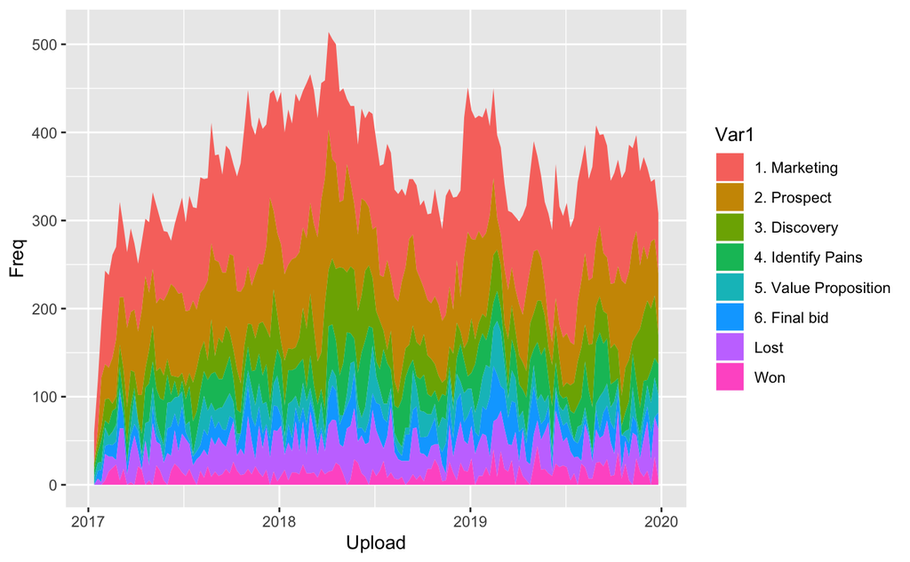

```r
library(tidyverse)
ggplot(data_for_plot) + geom_area(mapping = aes(x = Upload, y = Freq, fill = Var1))
library(ggplot2)
ggsave('generated_data_plot.pdf', width = 30, height = 20, units = "cm")
```

## Save data with dropped duplocates for closed opportunities

```r
write.csv(data_dropped_closed_duplicates, 'data_complete_no_closed_duplicates.csv')
```